# GAM

Maria Carolina Pacheco

## 1 Introdução

Os dados que vou usar para esta análise seguem a mesma estrutura dos dados que utilizei no script anterior, no qual fiz um glm utilizando distribuição Beta. A diferença é que estes dados são de outro experimento realizado com corais da espécie *Porites Astreoides*.

Assim, temos:

- Variável resposta: YII
- Variáveis preditoras: tratamento (aquecido x controle); habitat (topo x base); dias de experimento

Abrindo os dados e já convertendo em fator o que vou utilizar:

```r
micro_porites <- read.csv("dados_scriptsR/PAM_porites.csv", sep=";", dec=".")
View(micro_porites)
str(micro_porites)
```

```
## 'data.frame':    1172 obs. of  20 variables:
##  $ day          : int  15 19 22 25 29 15 19 22 25 29 ...
##  $ month        : int  4 4 4 4 4 4 4 4 4 4 ...
##  $ year         : int  2025 2025 2025 2025 2025 2025 2025 2025 2025 2025 ...
##  $ sp           : chr  "Porites_astreoides" "Porites_astreoides" "Porites_astreoides" "Porites_astreoides" ...
##  $ sp_code      : chr  "P" "P" "P" "P" ...
##  $ exp_day      : int  0 4 7 10 14 0 4 7 10 14 ...
##  $ habitat      : chr  "T" "T" "T" "T" ...
##  $ treatment    : chr  "C" "C" "C" "C" ...
##  $ system       : int  4 4 4 4 4 1 1 1 1 1 ...
##  $ colony       : chr  "A" "A" "A" "A" ...
##  $ fragment     : int  2 2 2 2 2 3 3 3 3 3 ...
##  $ ID           : chr  "PTA2" "PTA2" "PTA2" "PTA2" ...
##  $ label        : int  2 2 2 2 2 3 3 3 3 3 ...
##  $ pam1         : num  0.471 0.487 0.844 0.55 0.596 0.833 0.6 0.795 0.476 0.469 ...
##  $ pam2         : num  0.689 0.833 0.746 0.505 0.636 0.819 0.585 0.782 0.66 0.756 ...
##  $ pam3         : num  0.875 0.775 0.772 0.6 0.817 0.75 0.598 0.718 0.569 0.556 ...
##  $ YII          : num  0.678 0.698 0.787 0.552 0.683 0.801 0.594 0.765 0.568 0.594 ...
##  $ offset       : int  69 67 69 72 69 69 70 68 68 68 ...
##  $ treat_colony : chr  "CA" "CA" "CA" "CA" ...
##  $ habitat_treat: chr  "TC" "TC" "TC" "TC" ...
```

```r
cols_p <- c("habitat", "treatment", "colony", "ID")
micro_porites[, cols_p] <- lapply(micro_porites[, cols_p], factor) #Transformando para fator
```

## 2 Explorando os dados visualmente

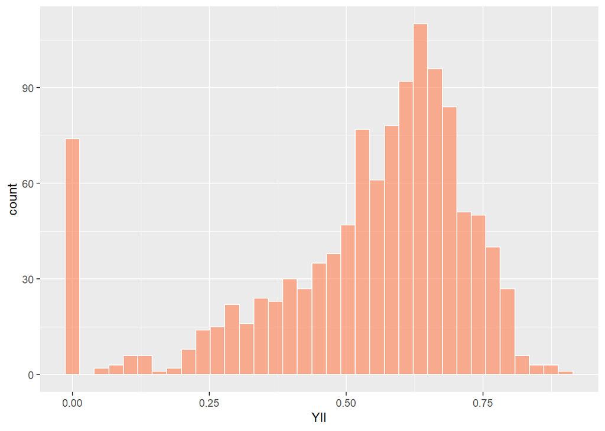

```r
# Distribuição da variável resposta
ggplot(micro_porites, aes(x = YII)) +
  geom_histogram(bins = 35, fill = 'coral', col = 'white', alpha = 0.6)
```

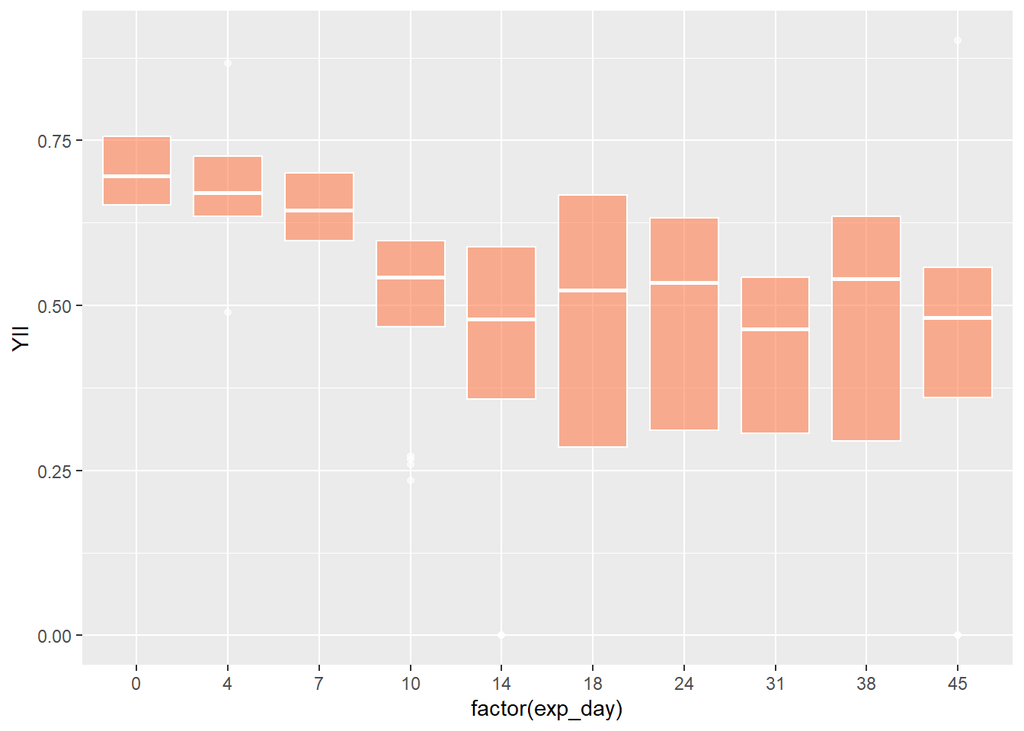

```r
#Plotando os dados ao longo do tempo
ggplot(micro_porites, aes(x = factor(exp_day) , y=YII)) +
  geom_boxplot(fill = 'coral', col = 'white', alpha = 0.6)
```

A eficiência fotossintética parece diminuir ao longo do tempo

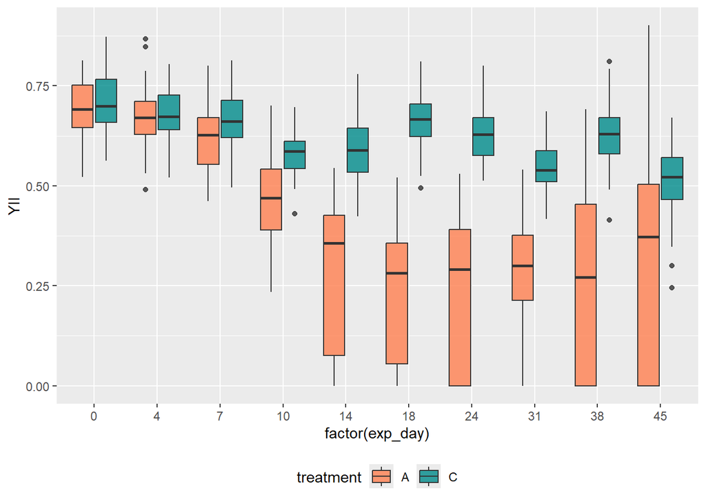

```r
#Separando por tratamento
ggplot(micro_porites, aes(x = factor(exp_day) , y=YII, fill=treatment)) +
  geom_boxplot(alpha = 0.8)+
  scale_fill_manual(values=c("coral","cyan4"))+
  theme(legend.position = "bottom")
```

O experimento parece ter funcionado bem, considerando que estamos vendo uma diferença entre os tratamentos conforme o esperado.

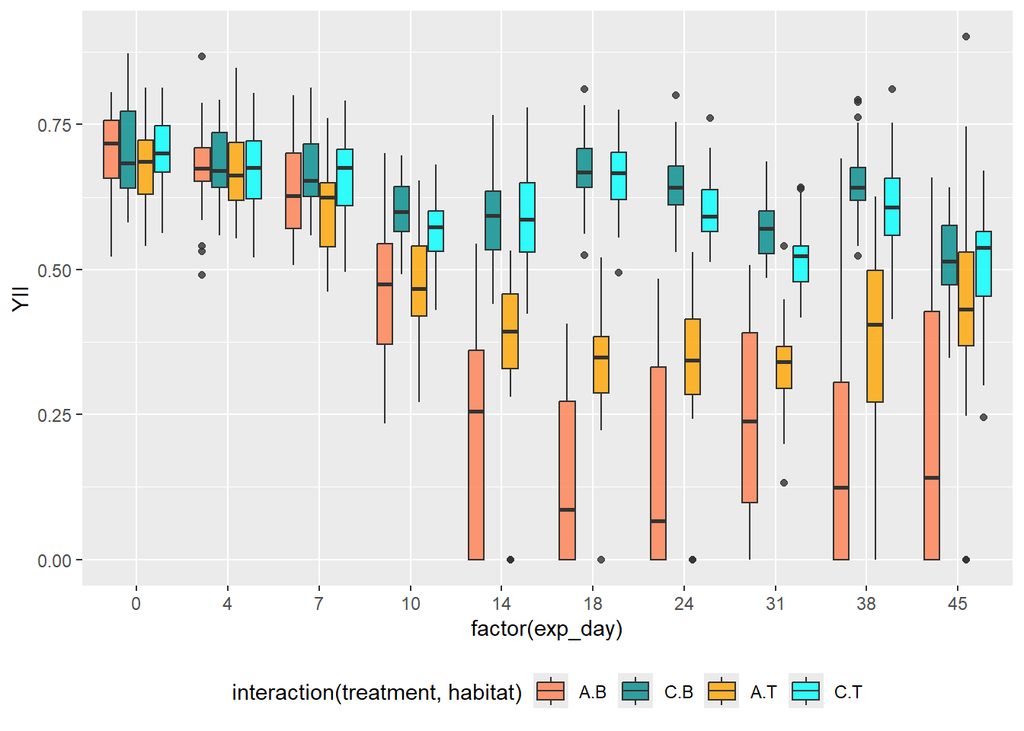

```r
#Separando agora por habitat também
ggplot(micro_porites, aes(x = factor(exp_day) , y=YII, fill=interaction (treatment, habitat)))+
  geom_boxplot(alpha = 0.8)+
  scale_fill_manual(values=c("coral","cyan4", "orange", "cyan"))+
  theme(legend.position = "bottom")
```

Essa espécie parece ter uma diferenciação maior entre topo e base.

## 3 Modelos

Vou começar rodando um GLMM como fiz com Siderastrea stellata no script anterior.

### 3.1 Modelo 1: GLMM

```r
summary(micro_porites$YII)
```

```
##    Min. 1st Qu.  Median    Mean 3rd Qu.    Max.
##  0.0000  0.4540  0.5885  0.5332  0.6660  0.9010
```

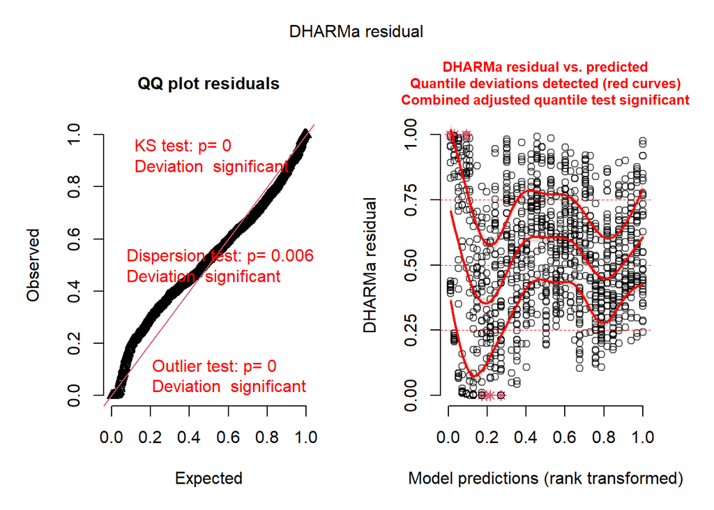

```r
micro_porites$YII <- (micro_porites$YII + (median(micro_porites$YII, na.rm = TRUE)*0.1)) #ajustando os dados para eliminar zeros

# Fazendo um modelo já com todos os preditores e incluindo interação
glmm_porites <- glmmTMB (YII ~ treatment*exp_day*habitat +
                        (1|ID),
                      family = beta_family(link="logit"),
                      data = micro_porites)

# Avaliando o ajuste do modelo visualmente
simres_glmm_por <- simulateResiduals(glmm_porites, n=1000)
plot(simres_glmm_por) #bem ruim, não parece linear
```

```r
check_model(simres_glmm_por) #o modelo não tá prevendo bem a distribuição dos residuos
```

```
## `check_outliers()` does not yet support models of class `glmmTMB`.
```

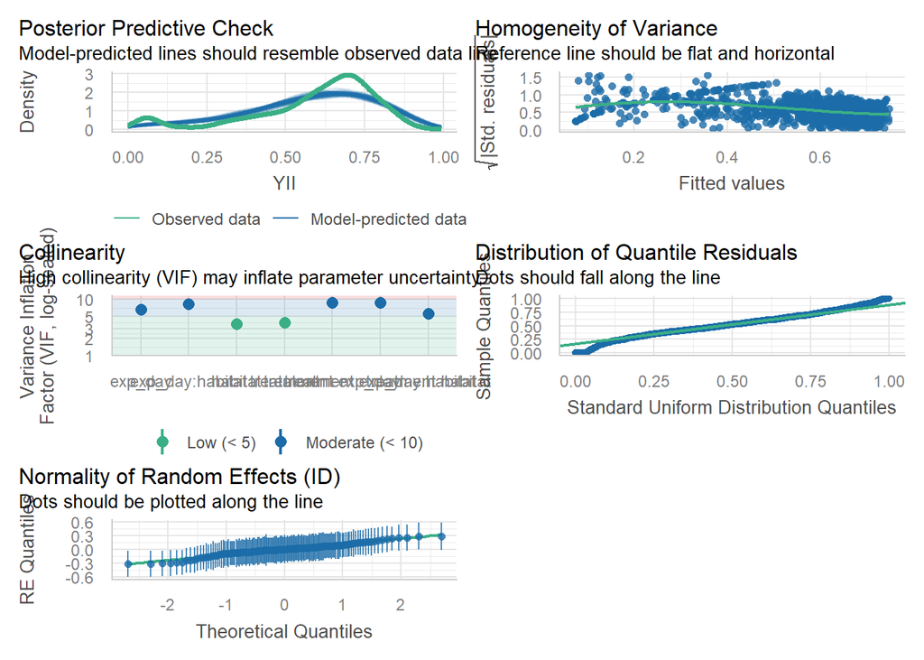

Avaliando os resíduos do modelo, é possível concluir que ele não está bem ajustado aos dados. O QQ plot mostrou desvio significativo do resíduos e, utilizando a função check_model, vemos que os dados observados não estão seguindo a linha dos dados previstos.

Vamos testar usando GAMM.

### 3.2 Modelo 2: GAMM

```r
gamm_porites <- gam(YII ~ s(exp_day, bs = "tp") + treatment + habitat +
                     s(ID, bs="re"), #colocando o id dos corais como efeito aleatório
                   data = micro_porites,
                   family = betar(link="logit"))
```

### 3.3 Comparando e visualizando

```r
AIC (glmm_porites, gamm_porites )
```

```
##                    df       AIC
## glmm_porites 10.00000 -1282.680
## gamm_porites 99.90286 -1409.919
```

Utilizando GAMM o AIC ficou menor, então vamos adotar esse modelo.

Visualizando os resultados agora:

```r
summary(gamm_porites)
```

```
##
## Family: Beta regression(11.777)
## Link function: logit
##
## Formula:
## YII ~ s(exp_day, bs = "tp") + treatment + habitat + s(ID, bs = "re")
##
## Parametric coefficients:
##             Estimate Std. Error z value Pr(>|z|)
## (Intercept) -0.14022    0.05073  -2.764  0.00571 **
## treatmentC   0.82464    0.05722  14.411  < 2e-16 ***
## habitatT     0.15652    0.05908   2.649  0.00807 **
## ---
## Signif. codes:  0 '***' 0.001 '**' 0.01 '*' 0.05 '.' 0.1 ' ' 1
##
## Approximate significance of smooth terms:
##               edf  Ref.df Chi.sq p-value
## s(exp_day)  7.514   8.379  795.8  <2e-16 ***
## s(ID)      87.186 138.000  258.9  <2e-16 ***
## ---
## Signif. codes:  0 '***' 0.001 '**' 0.01 '*' 0.05 '.' 0.1 ' ' 1
##
## R-sq.(adj) =  0.633   Deviance explained =   66%
## -REML = -664.13  Scale est. = 1         n = 1172
```

O modelo mostra efeito significativo tanto do tratamento quanto do habitat de origem dos corais. Os efeitos do tempo e do coral também foram significativos.

Checando o ajuste:

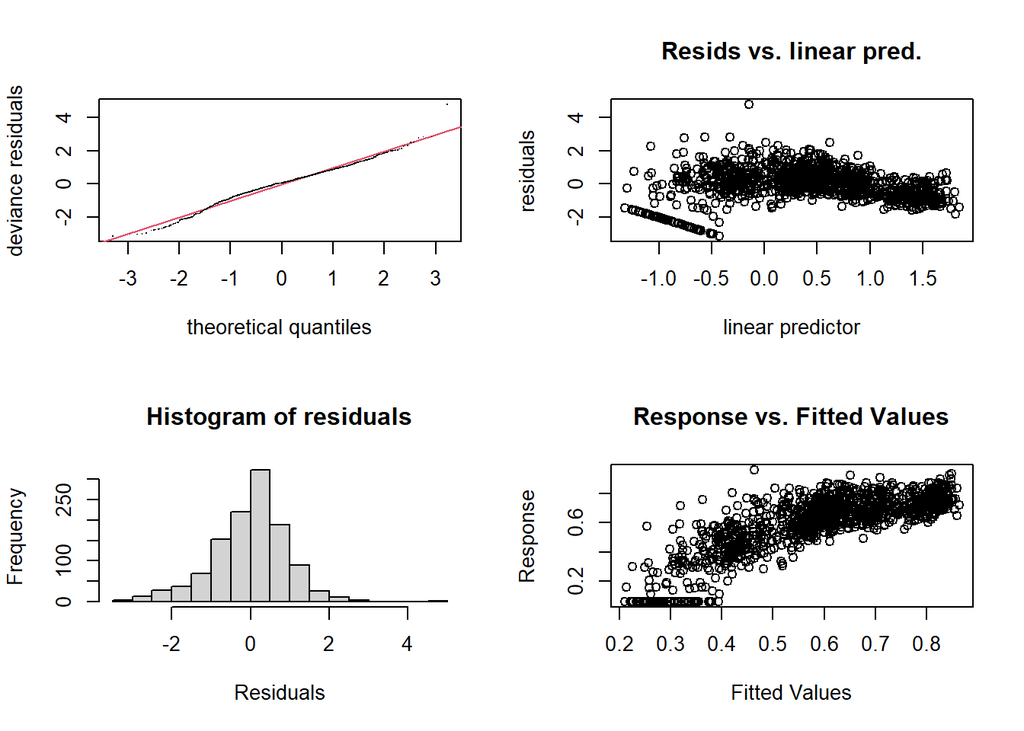

```
##
## Method: REML   Optimizer: outer newton
## full convergence after 7 iterations.
## Gradient range [1.270734e-07,1.844492e-06]
## (score -664.1319 & scale 1).
## Hessian positive definite, eigenvalue range [2.440632,561.5133].
## Model rank =  152 / 152
##
## Basis dimension (k) checking results. Low p-value (k-index<1) may
## indicate that k is too low, especially if edf is close to k'.
##
##                k'    edf k-index p-value
## s(exp_day)   9.00   7.51    0.83  <2e-16 ***
## s(ID)      140.00  87.19      NA      NA
## ---
## Signif. codes:  0 '***' 0.001 '**' 0.01 '*' 0.05 '.' 0.1 ' ' 1
```

```r
par(mfrow = c(2,2))
gam.check(gamm_porites) # Aqui parece bom
```

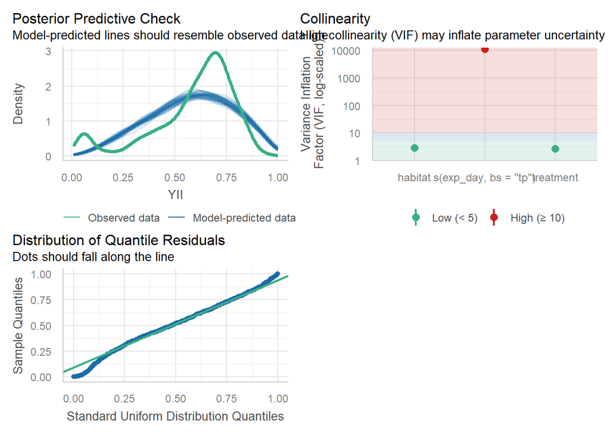

```r
check_model(gamm_porites) #Aqui parece péssimo
```

Ainda preciso fazer ajustes no modelo para poder fazer ele prever melhor os meus dados.